# 1. Phân tích sơ bộ dữ liệu

```python
import pandas as pd
import matplotlib.pyplot as plt
import seaborn as sns
import numpy as np
from pathlib import Path

# Đọc dữ liệu (use raw string / Path to avoid unicode escape errors)
data_path = Path(r'D:\\PTDL\\LAB1_PTDL\\xu_ly_truc_quan_hoa_du_lieu\\bai_thuc_hanh_2\\Benh_tieu_duong\\data\\diabetes.csv')
if not data_path.exists():
    raise FileNotFoundError(f'CSV file not found at: {data_path} - check the path')
diabetes_data = pd.read_csv(data_path)
print('Kích thước dữ liệu:', diabetes_data.shape)
print('\nThông tin cột:')
print(diabetes_data.columns.tolist())
print('\n5 dòng đầu tiên:')
print(diabetes_data.head())
print('\nThống kê mô tả:')
print(diabetes_data.describe())
```

```
Kích thước dữ liệu: (768, 9)

Thông tin cột:
['Pregnancies', 'Glucose', 'BloodPressure', 'SkinThickness', 'Insulin', 'BMI', 'DiabetesPedigreeFunction', 'Age', 'Outcome']

5 dòng đầu tiên:
   Pregnancies  Glucose  BloodPressure  SkinThickness  Insulin   BMI  \
0            6      148             72             35        0  33.6
1            1       85             66             29        0  26.6
2            8      183             64              0        0  23.3
3            1       89             66             23       94  28.1
4            0      137             40             35      168  43.1

   DiabetesPedigreeFunction  Age  Outcome
0                     0.627   50        1
1                     0.351   31        0
2                     0.672   32        1
3                     0.167   21        0
4                     2.288   33        1

Thống kê mô tả:
       Pregnancies     Glucose  BloodPressure  SkinThickness     Insulin  \
count   768.000000  768.000000     768.000000     768.000000  768.000000
mean      3.845052  120.894531      69.105469      20.536458   79.799479
std       3.369578   31.972618      19.355807      15.952218  115.244002
min       0.000000    0.000000       0.000000       0.000000    0.000000
25%       1.000000   99.000000      62.000000       0.000000    0.000000
50%       3.000000  117.000000      72.000000      23.000000   30.500000
75%       6.000000  140.250000      80.000000      32.000000  127.250000
max      17.000000  199.000000     122.000000      99.000000  846.000000

              BMI  DiabetesPedigreeFunction         Age     Outcome
count  768.000000                768.000000  768.000000  768.000000
mean    31.992578                  0.471876   33.240885    0.348958
std      7.884160                  0.331329   11.760232    0.476951
min      0.000000                  0.078000   21.000000    0.000000
25%     27.300000                  0.243750   24.000000    0.000000
50%     32.000000                  0.372500   29.000000    0.000000
75%     36.600000                  0.626250   41.000000    1.000000
max     67.100000                  2.420000   81.000000    1.000000
```

### Kết quả:

- Dữ liệu gồm 768 mẫu với 9 đặc trưng
- Các biến: Pregnancies, Glucose, BloodPressure, SkinThickness, Insulin, BMI, DiabetesPedigreeFunction, Age, Outcome
- Outcome là biến mục tiêu (0: không mắc bệnh, 1: mắc bệnh)

# 2. Trực quan hóa với Matplotlib

## Case 1: Phân bố kết quả bệnh tiểu đường

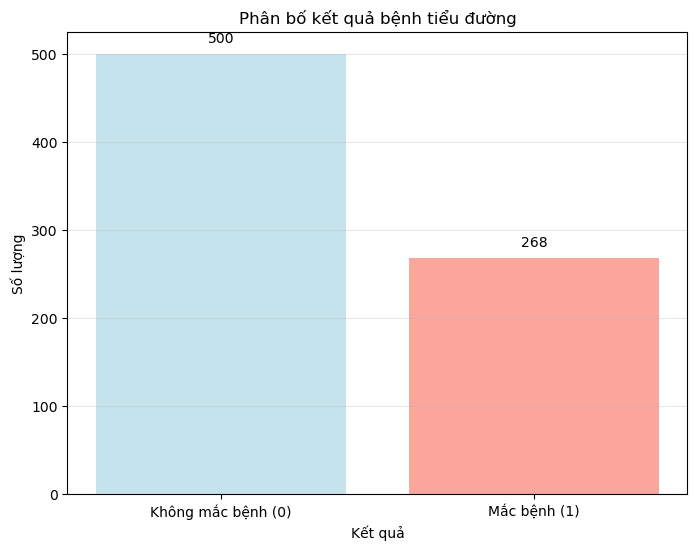

```python
plt.figure(figsize=(8, 6))
outcome_counts = diabetes_data['Outcome'].value_counts()
plt.bar(['Không mắc bệnh (0)', 'Mắc bệnh (1)'], outcome_counts.values,
        color=['lightblue', 'salmon'], alpha=0.7)
plt.xlabel('Kết quả')
plt.ylabel('Số lượng')
plt.title('Phân bố kết quả bệnh tiểu đường')
for i, v in enumerate(outcome_counts.values):
    plt.text(i, v + 10, str(v), ha='center', va='bottom')
plt.grid(axis='y', alpha=0.3)
plt.show()
```

### Nhận xét:

Dữ liệu không cân bằng với khoảng 500 trường hợp không mắc bệnh và 268 trường hợp mắc bệnh.

## Case 2: So sánh Glucose theo kết quả bệnh

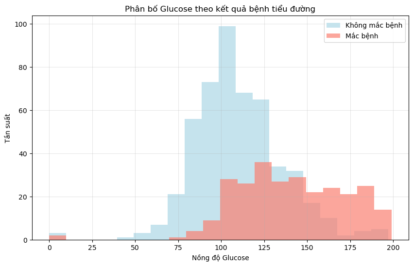

```python
plt.figure(figsize=(10, 6))

# Tách dữ liệu theo outcome
glucose_0 = diabetes_data[diabetes_data['Outcome'] == 0]['Glucose']
glucose_1 = diabetes_data[diabetes_data['Outcome'] == 1]['Glucose']

plt.hist(glucose_0, bins=20, alpha=0.7, label='Không mắc bệnh', color='lightblue')
plt.hist(glucose_1, bins=20, alpha=0.7, label='Mắc bệnh', color='salmon')

plt.xlabel('Nồng độ Glucose')
plt.ylabel('Tần suất')
plt.title('Phân bố Glucose theo kết quả bệnh tiểu đường')
plt.legend()
plt.grid(alpha=0.3)
plt.show()
```

### Nhận xét:

Người mắc bệnh tiểu đường có xu hướng có nồng độ glucose cao hơn.

## Case 3: Mối quan hệ giữa Tuổi và BMI

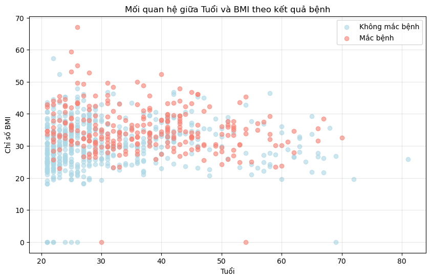

```python
plt.figure(figsize=(10, 6))
colors = ['lightblue', 'salmon']
outcomes = [0, 1]
labels = ['Không mắc bệnh', 'Mắc bệnh']

for i, outcome in enumerate(outcomes):
    subset = diabetes_data[diabetes_data['Outcome'] == outcome]
    plt.scatter(subset['Age'], subset['BMI'],
               alpha=0.6, c=colors[i], label=labels[i])

plt.xlabel('Tuổi')
plt.ylabel('Chỉ số BMI')
plt.title('Mối quan hệ giữa Tuổi và BMI theo kết quả bệnh')
plt.legend()
plt.grid(alpha=0.3)
plt.show()
```

### Nhận xét:

Không có mối quan hệ rõ ràng giữa tuổi và BMI với kết quả bệnh.